# Project 1: Exploratory Data Analysis

SDS348

## Data Wrangling and Data Exploration

### Instructions

A knitted R Markdown document (ideally HTML) and the raw R Markdown file (as .Rmd) should both be submitted to Canvas by 11:59pm on the due date. These two documents will be graded jointly, so they must be consistent (i.e., don’t change the R Markdown file without also updating the knitted document).

The text of the document should provide a narrative structure around your code/output. All results presented must have corresponding code. Any answers/results/plots etc. given without the corresponding R code that generated the result will not be considered. Furthermore, all code contained in your final project document must work correctly (knit early, knit often)! Please do not include any extraneous code or code which produces error messages. (Code that produces warnings is acceptable, as long as you understand what the warnings mean!)

### Find data:

Find two (!) datasets with one variable in common (e.g., dates, times, states, counties, countries, sports players), both with at least 50 observations (i.e., rows) in each. Please think very carefully about whether it makes sense to combine your datasets! If you find one dataset with 50 patients and it has their age, and you find another dataset with 50 *different* patients that has their ages, it makes no sense to join them based on age (you would just be pairing up random people of the same age).

When combined, the resulting/final dataset must have **at least 4 different variables (at least 3 numeric) in addition to the common variable** (i.e., five variables total).

You can have as many variables as you would like! If you found two datasets that you like but they don’t have enough variables, find a third dataset with the same common variable and join all three.

### Guidelines

1. If the datasets are not tidy, you will need to reshape them so that every observation has its own row and every variable its own column. If the datasets are both already tidy, you will make them untidy with `pivot_wider()/spread()` and then tidy them again with `pivot_longer/gather()` to demonstrate your use of the functions. It’s fine to wait until you have your descriptives to use these functions (e.g., you might want to pivot_wider() to rearrange the data to make your descriptive statistics easier to look at); it’s fine long as you use them at least once!

```r
library(tidyverse)
getwd()
```

```
## [1] "/Users/audreylee/Downloads"
```

```r
Drinks <- read.csv('drinks.csv')
Happiness <- read.csv('happiness.csv')
glimpse(Happiness)
```

```
## Rows: 156
## Columns: 9
## $ Overall.rank                 <int> 1, 2, 3, 4, 5, 6, 7, 8, 9, 10, 11, 12, 1…
## $ Country.or.region            <fct> Finland, Denmark, Norway, Iceland, Nethe…
## $ Score                        <dbl> 7.769, 7.600, 7.554, 7.494, 7.488, 7.480…
## $ GDP.per.capita               <dbl> 1.340, 1.383, 1.488, 1.380, 1.396, 1.452…
## $ Social.support               <dbl> 1.587, 1.573, 1.582, 1.624, 1.522, 1.526…
## $ Healthy.life.expectancy      <dbl> 0.986, 0.996, 1.028, 1.026, 0.999, 1.052…
## $ Freedom.to.make.life.choices <dbl> 0.596, 0.592, 0.603, 0.591, 0.557, 0.572…
## $ Generosity                   <dbl> 0.153, 0.252, 0.271, 0.354, 0.322, 0.263…
## $ Perceptions.of.corruption    <dbl> 0.393, 0.410, 0.341, 0.118, 0.298, 0.343…
```

```r
wide2 <-pivot_wider(Drinks,names_from="country",values_from="total_litres_of_pure_alcohol")
pivot_longer(wide2,cols = c("Afghanistan":"Zimbabwe"),names_to="Country",values_to="Total Liters of Alcohol")
```

```
## # A tibble: 35,319 x 6
##    beer_servings spirit_servings wine_servings continent Country
##            <int>           <int>         <int> <fct>     <chr>
##  1             0               0             0 Asia      Afghan…
##  2             0               0             0 Asia      Albania
##  3             0               0             0 Asia      Algeria
##  4             0               0             0 Asia      Andorra
##  5             0               0             0 Asia      Angola
##  6             0               0             0 Asia      Antigu…
##  7             0               0             0 Asia      Argent…
##  8             0               0             0 Asia      Armenia
##  9             0               0             0 Asia      Austra…
## 10             0               0             0 Asia      Austria
## # … with 35,309 more rows, and 1 more variable: `Total Liters of Alcohol` <dbl>
```

```r
wide <- pivot_wider(Happiness,names_from="Country.or.region",values_from="Score")
wide %>% pivot_longer(c("Finland":"South Sudan"),names_to="Country",values_to="Happiness_Score")
```

```
## # A tibble: 24,336 x 9
##    Overall.rank GDP.per.capita Social.support Healthy.life.ex… Freedom.to.make…
##           <int>          <dbl>          <dbl>            <dbl>            <dbl>
##  1            1           1.34           1.59            0.986            0.596
##  2            1           1.34           1.59            0.986            0.596
##  3            1           1.34           1.59            0.986            0.596
##  4            1           1.34           1.59            0.986            0.596
##  5            1           1.34           1.59            0.986            0.596
##  6            1           1.34           1.59            0.986            0.596
##  7            1           1.34           1.59            0.986            0.596
##  8            1           1.34           1.59            0.986            0.596
##  9            1           1.34           1.59            0.986            0.596
## 10            1           1.34           1.59            0.986            0.596
## # … with 24,326 more rows, and 4 more variables: Generosity <dbl>,
## #   Perceptions.of.corruption <dbl>, Country <chr>, Happiness_Score <dbl>
```

[output not shown]

2. Join your 2+ separate data sources into a single dataset based on a common ID variable! If you can’t find a good pair datasets to join, you may split one main dataset into two different datasets with a common ID variable in each, and then join them back together based on that common ID, but this is obviously less than ideal.

```r
Happiness <- Happiness%>%rename(country=Country.or.region)
data <- full_join(Happiness,Drinks,by="country")
nona <- na.omit(data)
```

```
- You will document the type of join that you do (left/right/inner/full), including a discussion of how many observations were in each dataset, which observations in each dataset were dropped (if any) and why you chose this particular join.
```

3. Create summary statistics
   - Use *all six* core `dplyr` functions (`filter, select, arrange, group_by, mutate, summarize`) to manipulate and explore your dataset. For mutate, create a new variable that is a function of at least one other variable, preferably using a dplyr vector function (see dplyr cheatsheet). It’s totally fine to use the `_if`, `_at`, `_all` versions of mutate/summarize instead (indeed, it is encouraged if you have lots of variables)
   - Create summary statistics (`mean, sd, var, n, quantile, min, max, n_distinct, cor`, etc) for each of your numeric variables both overall and after grouping by one of your categorical variables (either together or one-at-a-time; if you have two categorical variables, try to include at least one statistic based on a grouping of two categorical variables simultaneously).

   If you do not have any categorical variables, create one using mutate (e.g., with `case_when` or `ifelse`) to satisfy the `group_by` requirements above. Ideally, you will find a way to show these summary statistics in an easy-to-read table (e.g., by reshaping). (You might explore the kable package for making pretty tables!) If you have lots of numeric variables (e.g., 10+), or your categorical variables have too many categories, just pick a few (either numeric variables or categories of a categorical variable) and summarize based on those. It would be a good idea to show a correlation matrix for your numeric variables (you will need it to make one of your plots).

```r
mutated <- nona %>% mutate(total_servings=beer_servings+spirit_servings+wine_servings)
glimpse(mutated)
```

```
## Rows: 143
## Columns: 15
## $ Overall.rank                 <int> 1, 2, 3, 4, 5, 6, 7, 8, 9, 10, 11, 12, 1…
## $ country                      <fct> Finland, Denmark, Norway, Iceland, Nethe…
## $ Score                        <dbl> 7.769, 7.600, 7.554, 7.494, 7.488, 7.480…
## $ GDP.per.capita               <dbl> 1.340, 1.383, 1.488, 1.380, 1.396, 1.452…
## $ Social.support               <dbl> 1.587, 1.573, 1.582, 1.624, 1.522, 1.526…
## $ Healthy.life.expectancy      <dbl> 0.986, 0.996, 1.028, 1.026, 0.999, 1.052…
## $ Freedom.to.make.life.choices <dbl> 0.596, 0.592, 0.603, 0.591, 0.557, 0.572…
## $ Generosity                   <dbl> 0.153, 0.252, 0.271, 0.354, 0.322, 0.263…
## $ Perceptions.of.corruption    <dbl> 0.393, 0.410, 0.341, 0.118, 0.298, 0.343…
## $ beer_servings                <int> 263, 224, 169, 233, 251, 185, 152, 203, …
## $ spirit_servings              <int> 133, 81, 71, 61, 88, 100, 60, 79, 122, 7…
## $ wine_servings                <int> 97, 278, 129, 78, 190, 280, 186, 175, 10…
## $ total_litres_of_pure_alcohol <dbl> 10.0, 10.4, 6.7, 6.6, 9.4, 10.2, 7.2, 9.…
## $ continent                    <fct> Europe, Europe, Europe, Europe, Europe, …
## $ total_servings               <int> 493, 583, 369, 372, 529, 565, 398, 457, …
```

```r
mydata <- subset(mutated,select=-GDP.per.capita)
mydata <- subset(mydata,select=-Social.support)
mydata <- subset(mydata,select=-Healthy.life.expectancy)
mydata <- subset(mydata,select=-Freedom.to.make.life.choices)
mydata <- subset(mydata,select=-Generosity)
glimpse(mydata)
```

```
## Rows: 143
## Columns: 10
## $ Overall.rank                 <int> 1, 2, 3, 4, 5, 6, 7, 8, 9, 10, 11, 12, 1…
## $ country                      <fct> Finland, Denmark, Norway, Iceland, Nethe…
## $ Score                        <dbl> 7.769, 7.600, 7.554, 7.494, 7.488, 7.480…
## $ Perceptions.of.corruption    <dbl> 0.393, 0.410, 0.341, 0.118, 0.298, 0.343…
## $ beer_servings                <int> 263, 224, 169, 233, 251, 185, 152, 203, …
## $ spirit_servings              <int> 133, 81, 71, 61, 88, 100, 60, 79, 122, 7…
## $ wine_servings                <int> 97, 278, 129, 78, 190, 280, 186, 175, 10…
## $ total_litres_of_pure_alcohol <dbl> 10.0, 10.4, 6.7, 6.6, 9.4, 10.2, 7.2, 9.…
## $ continent                    <fct> Europe, Europe, Europe, Europe, Europe, …
## $ total_servings               <int> 493, 583, 369, 372, 529, 565, 398, 457, …
```

```r
mutated %>% filter(continent == "Asia")
```

```
##   Overall.rank              country Score GDP.per.capita Social.support
## 1           13               Israel 7.139          1.276          1.455
## 2           21 United Arab Emirates 6.825          1.503          1.310
## 3           28         Saudi Arabia 6.375          1.403          1.357
## 4           29                Qatar 6.374          1.684          1.313
## 5           34            Singapore 6.262          1.572          1.463
## 6           37              Bahrain 6.199          1.362          1.368
##   Healthy.life.expectancy Freedom.to.make.life.choices Generosity
## 1                   1.029                        0.371      0.261
## 2                   0.825                        0.598      0.262
## 3                   0.795                        0.439      0.080
## 4                   0.871                        0.555      0.220
## 5                   1.141                        0.556      0.271
## 6                   0.871                        0.536      0.255
##   Perceptions.of.corruption beer_servings spirit_servings wine_servings
## 1                     0.082            63              69             9
## 2                     0.182            16             135             5
## 3                     0.132             0               5             0
## 4                     0.167             1              42             7
## 5                     0.453            60              12            11
## 6                     0.110            42              63             7
##   total_litres_of_pure_alcohol continent total_servings
## 1                          2.5      Asia            141
## 2                          2.8      Asia            156
## 3                          0.1      Asia              5
## 4                          0.9      Asia             50
## 5                          1.5      Asia             83
## 6                          2.0      Asia            112
##  [ reached 'max' / getOption("max.print") -- omitted 32 rows ]
```

```r
mutated %>% filter(continent == "Africa")
```

```
##   Overall.rank   country Score GDP.per.capita Social.support
## 1           57 Mauritius 5.888          1.120          1.402
## 2           72     Libya 5.525          1.044          1.303
## 3           85   Nigeria 5.265          0.696          1.111
## 4           88   Algeria 5.211          1.002          1.160
## 5           89   Morocco 5.208          0.801          0.782
## 6           96  Cameroon 5.044          0.549          0.910
##   Healthy.life.expectancy Freedom.to.make.life.choices Generosity
## 1                   0.798                        0.498      0.215
## 2                   0.673                        0.416      0.133
## 3                   0.245                        0.426      0.215
## 4                   0.785                        0.086      0.073
## 5                   0.782                        0.418      0.036
## 6                   0.331                        0.381      0.187
##   Perceptions.of.corruption beer_servings spirit_servings wine_servings
## 1                     0.060            98              31            18
## 2                     0.152             0               0             0
## 3                     0.041            42               5             2
## 4                     0.114            25               0            14
## 5                     0.076            12               6            10
## 6                     0.037           147               1             4
##   total_litres_of_pure_alcohol continent total_servings
## 1                          2.6    Africa            147
## 2                          0.0    Africa              0
## 3                          9.1    Africa             49
## 4                          0.7    Africa             39
## 5                          0.5    Africa             28
## 6                          5.8    Africa            152
##  [ reached 'max' / getOption("max.print") -- omitted 35 rows ]
```

```r
mutated %>% filter(continent == "North America")
```

```
##   Overall.rank     country Score GDP.per.capita Social.support
## 1            9      Canada 7.278          1.365          1.505
## 2           12  Costa Rica 7.167          1.034          1.441
## 3           23      Mexico 6.595          1.070          1.323
## 4           27   Guatemala 6.436          0.800          1.269
## 5           31      Panama 6.321          1.149          1.442
## 6           35 El Salvador 6.253          0.794          1.242
##   Healthy.life.expectancy Freedom.to.make.life.choices Generosity
## 1                   1.039                        0.584      0.285
## 2                   0.963                        0.558      0.144
## 3                   0.861                        0.433      0.074
## 4                   0.746                        0.535      0.175
## 5                   0.910                        0.516      0.109
## 6                   0.789                        0.430      0.093
##   Perceptions.of.corruption beer_servings spirit_servings wine_servings
## 1                     0.308           240             122           100
## 2                     0.093           149              87            11
## 3                     0.073           238              68             5
## 4                     0.078            53              69             2
## 5                     0.054           285             104            18
## 6                     0.074            52              69             2
##   total_litres_of_pure_alcohol     continent total_servings
## 1                          8.2 North America            462
## 2                          4.4 North America            247
## 3                          5.5 North America            311
## 4                          2.2 North America            124
## 5                          7.2 North America            407
## 6                          2.2 North America            123
##  [ reached 'max' / getOption("max.print") -- omitted 6 rows ]
```

```r
mutated %>% filter(continent == "Europe")
```

```
##   Overall.rank     country Score GDP.per.capita Social.support
## 1            1     Finland 7.769          1.340          1.587
## 2            2     Denmark 7.600          1.383          1.573
## 3            3      Norway 7.554          1.488          1.582
## 4            4     Iceland 7.494          1.380          1.624
## 5            5 Netherlands 7.488          1.396          1.522
## 6            6 Switzerland 7.480          1.452          1.526
##   Healthy.life.expectancy Freedom.to.make.life.choices Generosity
## 1                   0.986                        0.596      0.153
## 2                   0.996                        0.592      0.252
## 3                   1.028                        0.603      0.271
## 4                   1.026                        0.591      0.354
## 5                   0.999                        0.557      0.322
## 6                   1.052                        0.572      0.263
##   Perceptions.of.corruption beer_servings spirit_servings wine_servings
## 1                     0.393           263             133            97
## 2                     0.410           224              81           278
## 3                     0.341           169              71           129
## 4                     0.118           233              61            78
## 5                     0.298           251              88           190
## 6                     0.343           185             100           280
##   total_litres_of_pure_alcohol continent total_servings
## 1                         10.0    Europe            493
## 2                         10.4    Europe            583
## 3                          6.7    Europe            369
## 4                          6.6    Europe            372
## 5                          9.4    Europe            529
## 6                         10.2    Europe            565
##  [ reached 'max' / getOption("max.print") -- omitted 34 rows ]
```

```r
mutated %>% filter(continent == "South America")
```

```
##   Overall.rank   country Score GDP.per.capita Social.support
## 1           26     Chile 6.444          1.159          1.369
## 2           32    Brazil 6.300          1.004          1.439
## 3           33   Uruguay 6.293          1.124          1.465
## 4           43  Colombia 6.125          0.985          1.410
## 5           47 Argentina 6.086          1.092          1.432
## 6           50   Ecuador 6.028          0.912          1.312
##   Healthy.life.expectancy Freedom.to.make.life.choices Generosity
## 1                   0.920                        0.357      0.187
## 2                   0.802                        0.390      0.099
## 3                   0.891                        0.523      0.127
## 4                   0.841                        0.470      0.099
## 5                   0.881                        0.471      0.066
## 6                   0.868                        0.498      0.126
##   Perceptions.of.corruption beer_servings spirit_servings wine_servings
## 1                     0.056           130             124           172
## 2                     0.086           245             145            16
## 3                     0.150           115              35           220
## 4                     0.034           159              76             3
## 5                     0.050           193              25           221
## 6                     0.087           162              74             3
##   total_litres_of_pure_alcohol     continent total_servings
## 1                          7.6 South America            426
## 2                          7.2 South America            406
## 3                          6.6 South America            370
## 4                          4.2 South America            238
## 5                          8.3 South America            439
## 6                          4.2 South America            239
##  [ reached 'max' / getOption("max.print") -- omitted 4 rows ]
```

```r
mydata %>% arrange(country,desc=T)
```

```
##    Overall.rank     country Score Perceptions.of.corruption beer_servings
## 1           154 Afghanistan 3.203                     0.025             0
## 2           107     Albania 4.719                     0.027            89
## 3            88     Algeria 5.211                     0.114            25
## 4            47   Argentina 6.086                     0.050           193
## 5           116     Armenia 4.559                     0.064            21
## 6            11   Australia 7.228                     0.290           261
## 7            10     Austria 7.246                     0.226           279
## 8            90  Azerbaijan 5.208                     0.182            21
## 9            37     Bahrain 6.199                     0.110            42
## 10          125  Bangladesh 4.456                     0.143             0
##    spirit_servings wine_servings total_litres_of_pure_alcohol     continent
## 1                0             0                          0.0          Asia
## 2              132            54                          4.9        Europe
## 3                0            14                          0.7        Africa
```

[output cut: 19 more lines]

```r
mean(mydata$Score)
```

```
## [1] 5.418811
```

```r
mean(mydata$Perceptions.of.corruption)
```

```
## [1] 0.1126573
```

```r
mean(mydata$beer_servings)
```

```
## [1] 111.7552
```

```r
mean(mydata$spirit_servings)
```

```
## [1] 77.37762
```

```r
mean(mydata$wine_servings)
```

```
## [1] 55.55944
```

```r
mean(mydata$total_litres_of_pure_alcohol)
```

```
## [1] 4.978322
```

```r
mean(mydata$total_servings)
```

```
## [1] 244.6923
```

```r
sd(mydata$Score)
```

```
## [1] 1.124369
```

```r
sd(mydata$Perceptions.of.corruption)
```

```
## [1] 0.09604628
```

```r
sd(mydata$beer_servings)
```

```
## [1] 106.3658
```

```r
sd(mydata$spirit_servings)
```

```
## [1] 79.62118
```

```r
sd(mydata$wine_servings)
```

```
## [1] 85.27302
```

```r
sd(mydata$total_litres_of_pure_alcohol)
```

```
## [1] 3.882103
```

```r
sd(mydata$total_servings)
```

```
## [1] 214.6208
```

```r
min(mydata$Score)
```

```
## [1] 3.083
```

```r
min(mydata$Perceptions.of.corruption)
```

```
## [1] 0
```

```r
min(mydata$beer_servings)
```

```
## [1] 0
```

```r
min(mydata$spirit_servings)
```

```
## [1] 0
```

```r
min(mydata$wine_servings)
```

```
## [1] 0
```

```r
min(mydata$total_litres_of_pure_alcohol)
```

```
## [1] 0
```

```r
min(mydata$total_servings)
```

```
## [1] 0
```

```r
max(mydata$Score)
```

```
## [1] 7.769
```

```r
max(mydata$Perceptions.of.corruption)
```

```
## [1] 0.453
```

```r
max(mydata$beer_servings)
```

```
## [1] 376
```

```r
max(mydata$spirit_servings)
```

```
## [1] 373
```

```r
max(mydata$wine_servings)
```

```
## [1] 370
```

```r
max(mydata$total_litres_of_pure_alcohol)
```

```
## [1] 14.4
```

```r
max(mydata$total_servings)
```

```
## [1] 665
```

```r
var(mydata$Score)
```

```
## [1] 1.264206
```

```r
var(mydata$Perceptions.of.corruption)
```

```
## [1] 0.009224889
```

```r
var(mydata$beer_servings)
```

```
## [1] 11313.68
```

```r
var(mydata$spirit_servings)
```

```
## [1] 6339.532
```

```r
var(mydata$wine_servings)
```

```
## [1] 7271.488
```

```r
var(mydata$total_litres_of_pure_alcohol)
```

```
## [1] 15.07072
```

```r
var(mydata$total_servings)
```

```
## [1] 46062.1
```

```r
n_distinct(mydata$Score)
```

```
## [1] 142
```

```r
n_distinct(mydata$Perceptions.of.corruption)
```

```
## [1] 105
```

```r
n_distinct(mydata$beer_servings)
```

```
## [1] 104
```

```r
n_distinct(mydata$spirit_servings)
```

```
## [1] 85
```

```r
n_distinct(mydata$wine_servings)
```

```
## [1] 66
```

```r
n_distinct(mydata$total_litres_of_pure_alcohol)
```

```
## [1] 76
```

```r
n_distinct(mydata$total_servings)
```

```
## [1] 116
```

```r
grouped <- mydata%>%group_by(continent)

mean(grouped$Score)
```

```
## [1] 5.418811
```

```r
mean(grouped$Perceptions.of.corruption)
```

```
## [1] 0.1126573
```

```r
mean(grouped$beer_servings)
```

```
## [1] 111.7552
```

```r
mean(grouped$spirit_servings)
```

```
## [1] 77.37762
```

```r
mean(grouped$wine_servings)
```

```
## [1] 55.55944
```

```r
mean(grouped$total_litres_of_pure_alcohol)
```

```
## [1] 4.978322
```

```r
mean(grouped$total_servings)
```

```
## [1] 244.6923
```

```r
sd(grouped$Score)
```

```
## [1] 1.124369
```

```r
sd(grouped$Perceptions.of.corruption)
```

```
## [1] 0.09604628
```

```r
sd(grouped$beer_servings)
```

```
## [1] 106.3658
```

```r
sd(grouped$spirit_servings)
```

```
## [1] 79.62118
```

```r
sd(grouped$wine_servings)
```

```
## [1] 85.27302
```

```r
sd(grouped$total_litres_of_pure_alcohol)
```

```
## [1] 3.882103
```

```r
sd(grouped$total_servings)
```

```
## [1] 214.6208
```

```r
min(grouped$Score)
```

```
## [1] 3.083
```

```r
min(grouped$Perceptions.of.corruption)
```

```
## [1] 0
```

```r
min(grouped$beer_servings)
```

```
## [1] 0
```

```r
min(grouped$spirit_servings)
```

```
## [1] 0
```

```r
min(grouped$wine_servings)
```

```
## [1] 0
```

```r
min(grouped$total_litres_of_pure_alcohol)
```

```
## [1] 0
```

```r
min(grouped$total_servings)
```

```
## [1] 0
```

```r
max(grouped$Score)
```

```
## [1] 7.769
```

```r
max(grouped$Perceptions.of.corruption)
```

```
## [1] 0.453
```

```r
max(grouped$beer_servings)
```

```
## [1] 376
```

```r
max(grouped$spirit_servings)
```

```
## [1] 373
```

```r
max(grouped$wine_servings)
```

```
## [1] 370
```

```r
max(grouped$total_litres_of_pure_alcohol)
```

```
## [1] 14.4
```

```r
max(grouped$total_servings)
```

```
## [1] 665
```

```r
var(grouped$Score)
```

```
## [1] 1.264206
```

```r
var(grouped$Perceptions.of.corruption)
```

```
## [1] 0.009224889
```

```r
var(grouped$beer_servings)
```

```
## [1] 11313.68
```

```r
var(grouped$spirit_servings)
```

```
## [1] 6339.532
```

```r
var(grouped$wine_servings)
```

```
## [1] 7271.488
```

```r
var(grouped$total_litres_of_pure_alcohol)
```

```
## [1] 15.07072
```

```r
var(grouped$total_servings)
```

```
## [1] 46062.1
```

```r
n_distinct(grouped$Score)
```

```
## [1] 142
```

```r
n_distinct(grouped$Perceptions.of.corruption)
```

```
## [1] 105
```

```r
n_distinct(grouped$beer_servings)
```

```
## [1] 104
```

```r
n_distinct(grouped$spirit_servings)
```

```
## [1] 85
```

```r
n_distinct(grouped$wine_servings)
```

```
## [1] 66
```

```r
n_distinct(grouped$total_litres_of_pure_alcohol)
```

```
## [1] 76
```

```r
n_distinct(grouped$total_servings)
```

```
## [1] 116
```

4. Make visualizations (three plots)
   - Make a correlation heatmap of your numeric variables
   - Create at least two additional plots of your choice with ggplot that highlight some of the more interesting features of your data.
   - Each plot (besides the heatmap) should have at least three variables mapped to separate aesthetics
   - Each should use different geoms (e.g., don’t do two geom_bars)
   - At least one plot should include `stat="summary"`
   - Each plot should include a supporting paragraph describing the relationships that are being visualized and any trends that are apparent
     - It is fine to include more, but limit yourself to 4. Plots should avoid being redundant! Four bad plots will get a lower grade than two good plots, all else being equal.
   - Make them pretty! Use correct labels, etc.

```r
library(dplyr)
library(tidyverse)
mydata %>% summarize(cor(Score,total_litres_of_pure_alcohol,use="pair"))
```

```
##   cor(Score, total_litres_of_pure_alcohol, use = "pair")
## 1                                              0.5006603
```

```r
mydata %>% summarize(cor(Score,total_servings,use="pair"))
```

```
##   cor(Score, total_servings, use = "pair")
## 1                                0.6128006
```

```r
cormat <- mydata %>% select_if(is.numeric) %>% cor(use="pair")
tidycor <- cormat %>% as.data.frame %>% rownames_to_column("var1") %>%  pivot_longer(-1,names_to="var2",values_to="correlation")
tidycor
```

```
## # A tibble: 64 x 3
##    var1         var2                         correlation
##    <chr>        <chr>                              <dbl>
##  1 Overall.rank Overall.rank                       1
##  2 Overall.rank Score                             -0.990
##  3 Overall.rank Perceptions.of.corruption         -0.366
##  4 Overall.rank beer_servings                     -0.557
##  5 Overall.rank spirit_servings                   -0.353
##  6 Overall.rank wine_servings                     -0.532
##  7 Overall.rank total_litres_of_pure_alcohol      -0.507
##  8 Overall.rank total_servings                    -0.618
##  9 Score        Overall.rank                      -0.990
## 10 Score        Score                              1
## # … with 54 more rows
```

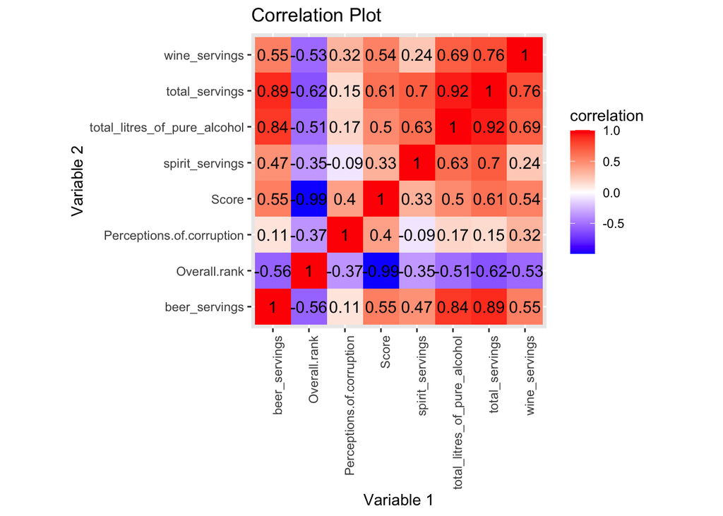

```r
tidycor%>%ggplot(aes(var1,var2,fill=correlation))+
geom_tile()+
scale_fill_gradient2(low="blue",mid="white",high="red")+
geom_text(aes(label=round(correlation,2)),color = "black", size = 4)+
theme(axis.text.x = element_text(angle = 90, hjust=1))+
coord_fixed()+xlab('Variable 1')+ylab('Variable 2')+ggtitle('Correlation Plot')
```

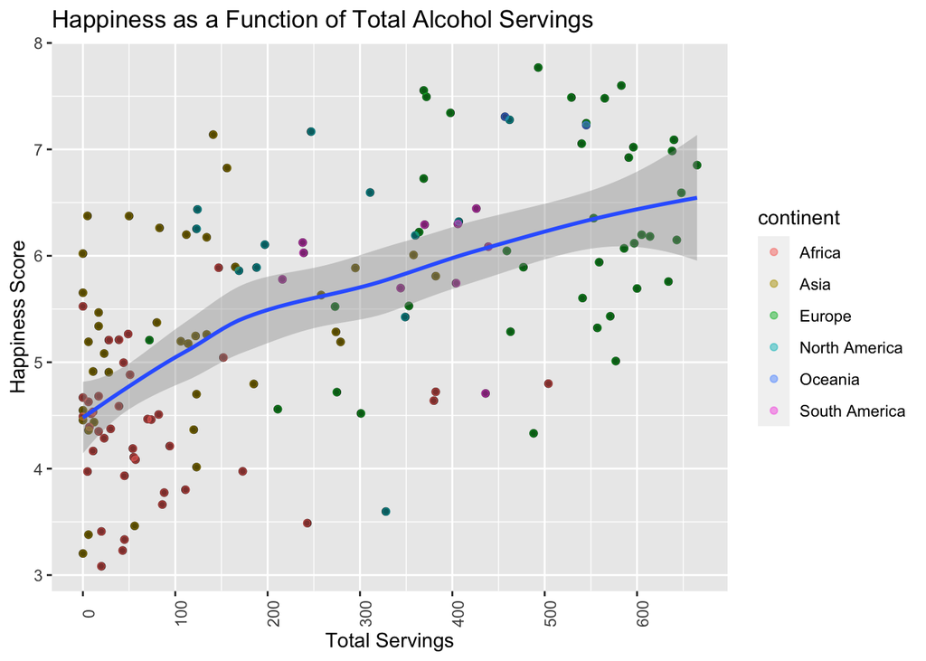

```r
ggplot(mydata,aes(x=total_servings,y=Score)) + geom_point()+geom_jitter(alpha=.5,aes(color=continent))+geom_smooth()+ggtitle("Happiness as a Function of Total Alcohol Servings")+xlab("Total Servings")+ylab("Happiness Score")+theme(axis.text.x = element_text(angle = 90))+scale_x_continuous(breaks=seq(0, 600, by = 100))
```

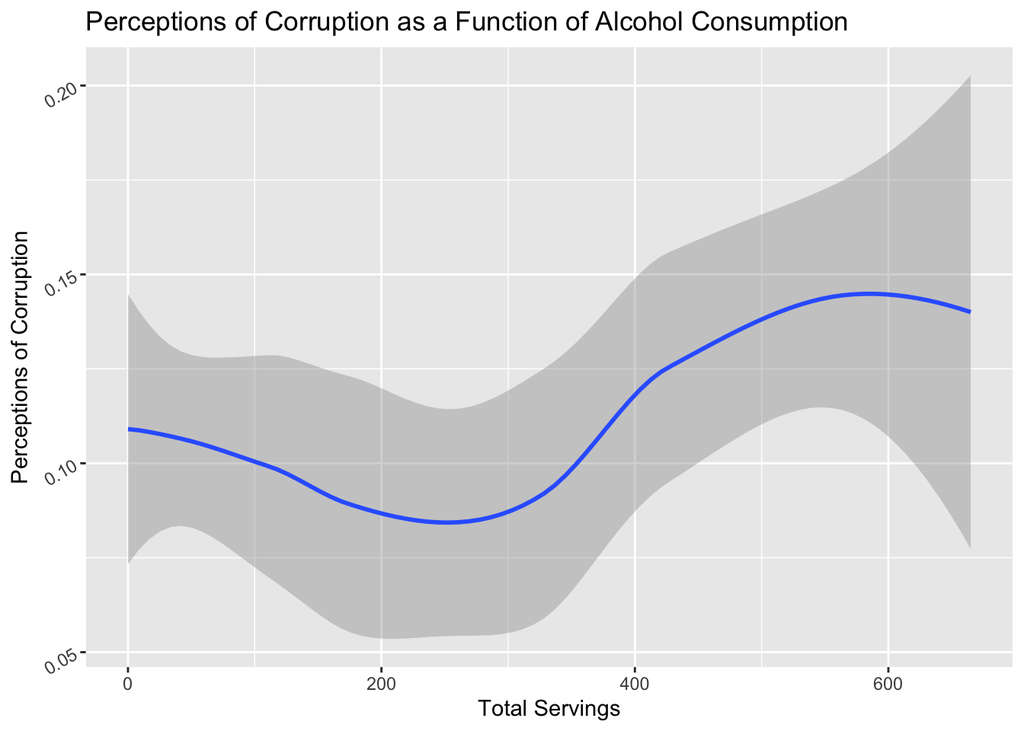

```r
ggplot(mydata,aes(x=total_servings,y=Perceptions.of.corruption))+geom_smooth()+ggtitle("Perceptions of Corruption as a Function of Alcohol Consumption")+xlab("Total Servings")+ylab("Perceptions of Corruption")+theme(axis.text.y = element_text(angle = 30))
```

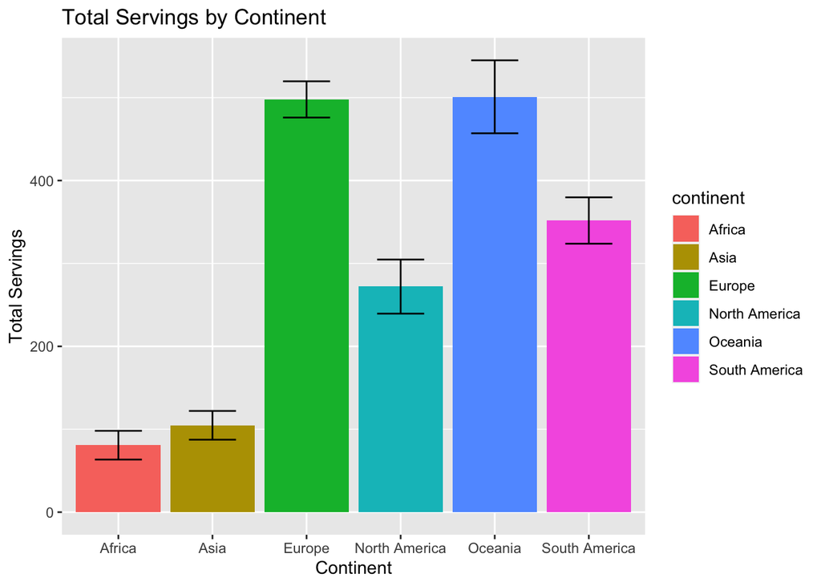

```r
ggplot(mydata, aes(x = continent, y = total_servings,fill=continent))+
  geom_bar(stat="summary",fun=mean)+
  geom_errorbar(stat="summary", fun.data=mean_se,width=0.5)+ggtitle('Total Servings by Continent')+xlab("Continent")+ylab("Total Servings")
```

5. Perform k-means/PAM clustering or PCA on (at least) your numeric variables.
   - Include all steps as we discuss in class, including a visualization.
   - If you don’t have at least 3 numeric variables, or you want to cluster based on categorical variables too, convert them to factors in R, generate Gower’s dissimilarity matrix on the data, and do PAM clustering on the dissimilarities.
   - Show how you chose the final number of clusters/principal components
   - Interpret the final clusters/principal components
   - For every step, document what your code does (in words) and what you see in the data!

```r
library(ggplot2)
library(tidyverse)
library(cluster)
clust_dat<-mydata%>%dplyr::select(beer_servings,Score)
num1<-vector()
for(i in 2:10){
  kms<-kmeans(clust_dat,centers=i)
  sil<-silhouette(kms$cluster,dist(clust_dat))
  sil_width<-mean(sil[,3])
}
ggplot()+geom_line(aes(x=1:10,y=sil_width))+scale_x_continuous(name="k",breaks=1:10)
```

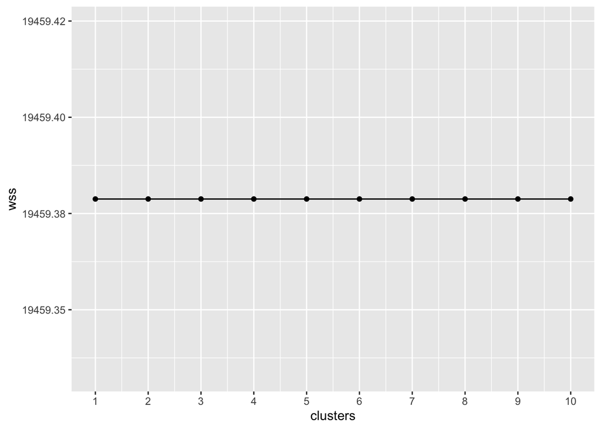

```r
for(i in 1:10){
temp<- mydata %>% select(beer_servings,Score) %>% kmeans(i)
wss<-temp$tot.withinss
}
ggplot()+geom_point(aes(x=1:10,y=wss))+geom_path(aes(x=1:10,y=wss))+
  xlab("clusters")+scale_x_continuous(breaks=1:10)
```

```r
kmeans1<-clust_dat%>%kmeans(10)
kmeans1
```

```
## K-means clustering with 10 clusters of sizes 16, 15, 16, 14, 12, 13, 22, 7, 16, 12
##
## Cluster means:
##    beer_servings    Score
## 1     20.8125000 4.778562
## 2     90.6000000 5.332067
## 3    149.1250000 6.018813
## 4      0.5714286 4.927000
## 5     37.5000000 4.628250
## 6     58.6923077 5.354000
## 7    215.9545455 6.214955
## 8    349.8571429 5.759000
## 9      7.5000000 4.431812
## 10   280.1666667 6.673417
##
## Clustering vector:
##   1   2   3   4   5   6   7   8   9  10  11  12  13  14  15  16  17  18  20  21
##  10   7   3   7  10   7   3   7   7  10  10   3   6   7   7  10   8  10   8   1
##  22  23  24  26  27  28  29  30  31  32  33  34  35  36  37  38  39  40  41  42
##   3   7   3   3   6   4   4  10  10   7   2   6   6   2   5   7   7   8   1   8
##  43  44  45  47  48  49  50  51  52  53  54  55  56  57  58  59  60  61  62  63
##   3  10   2   7  10   7   3   4   2  10   3   7   2   2   2   6   3   3   7   7
##  65  66  67  69  70  71  72  73  74  75  77  79  80  81  82  83  85  86  87  88
##   3   7   4   6  10   2   4   5   4   7   7   6   9   3   3   2   5   5   1   1
##  89  90  91  92  93  94  95  96  97  98 100 101 102 104 105 106 107 108 109 111
##   9   1   1   9   2   2   1   3   7   5   9   9   5   8   6   7   2   8   6   9
##  [ reached getOption("max.print") -- omitted 43 entries ]
##
## Within cluster sum of squares by cluster:
##  [1]  216.51136 2337.78019 3648.79481   24.35633  399.68727  572.89923
##  [7] 7689.36780 1215.16860  103.88163 3250.93155
##  (between_SS / total_SS =  98.8 %)
##
## Available components:
##
## [1] "cluster"      "centers"      "totss"        "withinss"     "tot.withinss"
## [6] "betweenss"    "size"         "iter"         "ifault"
```

```r
kmeans1$betweenss
```

```
## [1] 1587263
```

```r
kmeans1$tot.withinss
```

```
## [1] 19459.38
```

```r
kmeans1$size
```

```
##  [1] 16 15 16 14 12 13 22  7 16 12
```

```r
kmeans1$cluster
```

```
##   1   2   3   4   5   6   7   8   9  10  11  12  13  14  15  16  17  18  20  21
##  10   7   3   7  10   7   3   7   7  10  10   3   6   7   7  10   8  10   8   1
##  22  23  24  26  27  28  29  30  31  32  33  34  35  36  37  38  39  40  41  42
##   3   7   3   3   6   4   4  10  10   7   2   6   6   2   5   7   7   8   1   8
##  43  44  45  47  48  49  50  51  52  53  54  55  56  57  58  59  60  61  62  63
##   3  10   2   7  10   7   3   4   2  10   3   7   2   2   2   6   3   3   7   7
##  65  66  67  69  70  71  72  73  74  75  77  79  80  81  82  83  85  86  87  88
##   3   7   4   6  10   2   4   5   4   7   7   6   9   3   3   2   5   5   1   1
##  89  90  91  92  93  94  95  96  97  98 100 101 102 104 105 106 107 108 109 111
##   9   1   1   9   2   2   1   3   7   5   9   9   5   8   6   7   2   8   6   9
##  [ reached getOption("max.print") -- omitted 43 entries ]
```

```r
kmeansclust<-clust_dat%>%mutate(cluster=as.factor(kmeans1$cluster))
kmeansclust
```

```
##    beer_servings Score cluster
## 1            263 7.769      10
## 2            224 7.600       7
## 3            169 7.554       3
## 4            233 7.494       7
## 5            251 7.488      10
## 6            185 7.480       7
## 7            152 7.343       3
## 8            203 7.307       7
## 9            240 7.278       7
## 10           279 7.246      10
## 11           261 7.228      10
## 12           149 7.167       3
## 13            63 7.139       6
## 14           236 7.090       7
```

[output cut: 20 more lines]

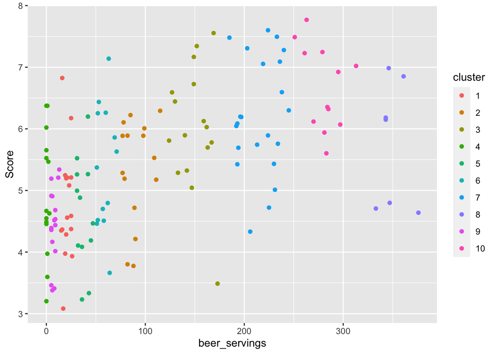

```r
kmeansclust%>%ggplot(aes(beer_servings,Score,color=cluster))+geom_point()
```

```r
clust_dat1<-mydata%>%dplyr::select(wine_servings,Score)
for(i in 2:10){
  kms1<-kmeans(clust_dat1,centers=i)
  sil1<-silhouette(kms1$cluster,dist(clust_dat1))
  sil_width1<-mean(sil[,3])
}
ggplot()+geom_line(aes(x=1:10,y=sil_width))+scale_x_continuous(name="k",breaks=1:10)
```

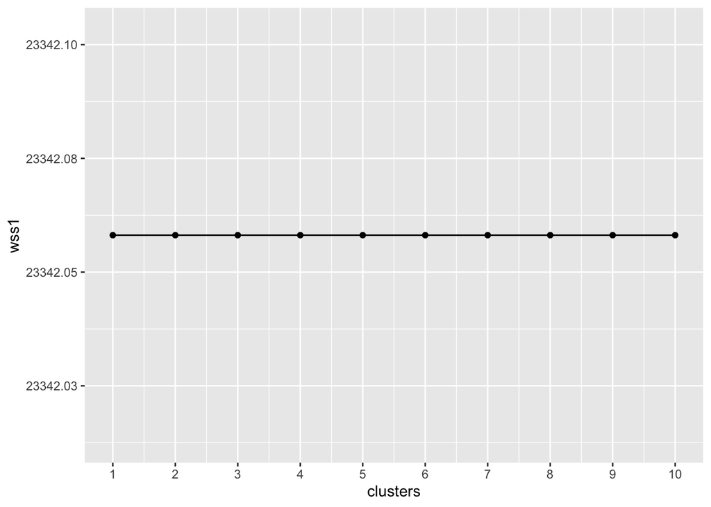

```r
for(i in 1:10){
temp1<- mydata %>% select(wine_servings,Score) %>% kmeans(i)
wss1<-temp1$tot.withinss
}
ggplot()+geom_point(aes(x=1:10,y=wss1))+geom_path(aes(x=1:10,y=wss1))+
  xlab("clusters")+scale_x_continuous(breaks=1:10)
```

```r
kmeans2<-clust_dat1%>%kmeans(10)
kmeans2
```

```
## K-means clustering with 10 clusters of sizes 5, 7, 10, 21, 17, 12, 16, 33, 9, 13
##
## Cluster means:
##    wine_servings    Score
## 1     37.0000000 4.717400
## 2    295.4285714 6.572143
## 3     17.6000000 5.284000
## 4      8.9523810 5.669905
## 5      0.7647059 5.664294
## 6      4.2500000 5.163500
## 7    195.0625000 6.672250
## 8      0.6666667 4.136636
## 9     64.3333333 5.737889
## 10   118.6153846 6.171462
##
## Clustering vector:
##   1   2   3   4   5   6   7   8   9  10  11  12  13  14  15  16  17  18  20  21
##  10   2  10   9   7   2   7   7  10   7   7   4   4   2   7   7   7   7  10   6
##  22  23  24  26  27  28  29  30  31  32  33  34  35  36  37  38  39  40  41  42
##  10   6   2   7   5   5   4  10   3   3   7   4   5   7   4  10   4   9   4   9
##  43  44  45  47  48  49  50  51  52  53  54  55  56  57  58  59  60  61  62  63
##   6   2   5   7   7  10   6   5   5   9   4   9   4   3   3   5   4   4   7   9
##  65  66  67  69  70  71  72  73  74  75  77  79  80  81  82  83  85  86  87  88
##   3   2   5   5  10   3   5  10   5   2   4   4   5   1   7   4   5   6   1   3
##  89  90  91  92  93  94  95  96  97  98 100 101 102 104 105 106 107 108 109 111
##   4   6   1   5   4   5   5   6  10   4   8   5   4   9  10   9   9   6   8   4
##  [ reached getOption("max.print") -- omitted 43 entries ]
##
## Within cluster sum of squares by cluster:
##  [1]   156.53720 10696.14261    48.90538    78.33232    14.68529    22.33410
##  [7]  7413.38077    25.40492   872.46678  2962.29815
##  (between_SS / total_SS =  97.8 %)
##
## Available components:
##
## [1] "cluster"      "centers"      "totss"        "withinss"     "tot.withinss"
## [6] "betweenss"    "size"         "iter"         "ifault"
```

```r
kmeans2$betweenss
```

```
## [1] 1010440
```

```r
kmeans2$tot.withinss
```

```
## [1] 22290.49
```

```r
kmeans2$size
```

```
##  [1]  5  7 10 21 17 12 16 33  9 13
```

```r
kmeans2$cluster
```

```
##   1   2   3   4   5   6   7   8   9  10  11  12  13  14  15  16  17  18  20  21
##  10   2  10   9   7   2   7   7  10   7   7   4   4   2   7   7   7   7  10   6
##  22  23  24  26  27  28  29  30  31  32  33  34  35  36  37  38  39  40  41  42
##  10   6   2   7   5   5   4  10   3   3   7   4   5   7   4  10   4   9   4   9
##  43  44  45  47  48  49  50  51  52  53  54  55  56  57  58  59  60  61  62  63
##   6   2   5   7   7  10   6   5   5   9   4   9   4   3   3   5   4   4   7   9
##  65  66  67  69  70  71  72  73  74  75  77  79  80  81  82  83  85  86  87  88
##   3   2   5   5  10   3   5  10   5   2   4   4   5   1   7   4   5   6   1   3
##  89  90  91  92  93  94  95  96  97  98 100 101 102 104 105 106 107 108 109 111
##   4   6   1   5   4   5   5   6  10   4   8   5   4   9  10   9   9   6   8   4
##  [ reached getOption("max.print") -- omitted 43 entries ]
```

```r
kmeansclust1<-clust_dat1%>%mutate(cluster=as.factor(kmeans2$cluster))
kmeansclust1
```

```
##    wine_servings Score cluster
## 1             97 7.769      10
## 2            278 7.600       2
## 3            129 7.554      10
## 4             78 7.494       9
## 5            190 7.488       7
## 6            280 7.480       2
## 7            186 7.343       7
## 8            175 7.307       7
## 9            100 7.278      10
## 10           191 7.246       7
## 11           212 7.228       7
## 12            11 7.167       4
## 13             9 7.139       4
## 14           271 7.090       2
```

[output cut: 20 more lines]

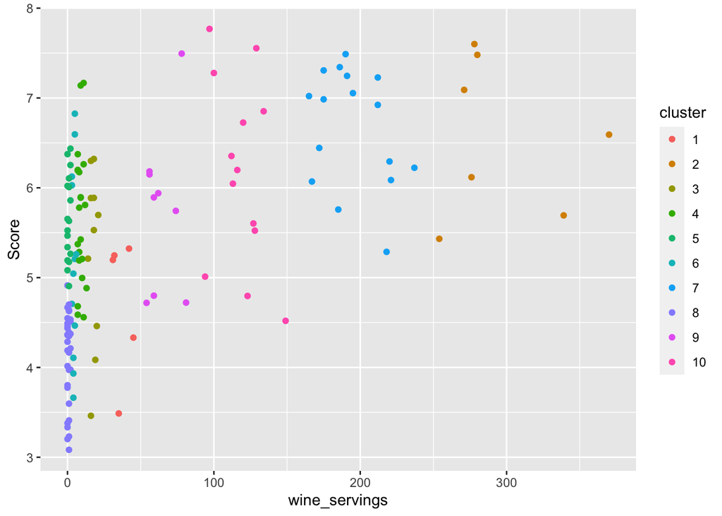

```r
kmeansclust1%>%ggplot(aes(wine_servings,Score,color=cluster))+geom_point()
```

```r
clust_dat2<-mydata%>%dplyr::select(spirit_servings,Score)
for(i in 2:10){
  kms2<-kmeans(clust_dat2,centers=i)
  sil2<-silhouette(kms2$cluster,dist(clust_dat2))
  sil_width2<-mean(sil[,3])
}
ggplot()+geom_line(aes(x=1:10,y=sil_width))+scale_x_continuous(name="k",breaks=1:10)
```

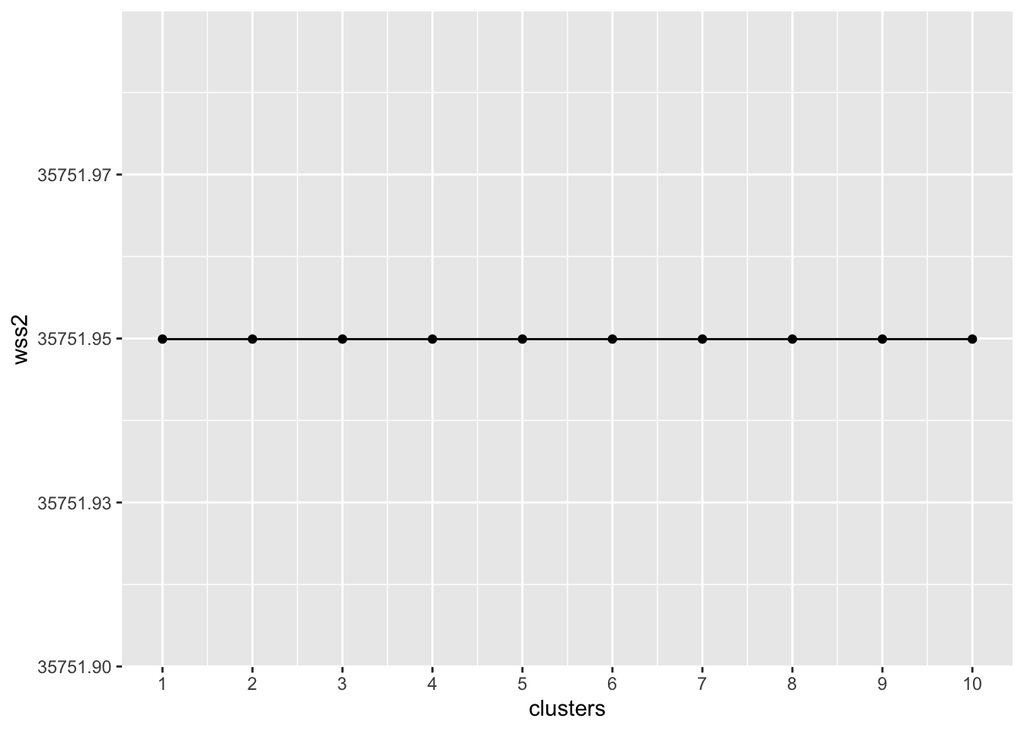

```r
for(i in 1:10){
temp2<- mydata %>% select(spirit_servings,Score) %>% kmeans(i)
wss2<-temp2$tot.withinss
}
ggplot()+geom_point(aes(x=1:10,y=wss2))+geom_path(aes(x=1:10,y=wss2))+
  xlab("clusters")+scale_x_continuous(breaks=1:10)
```

```r
kmeans3<-clust_dat%>%kmeans(10)
kmeans3
```

```
## K-means clustering with 10 clusters of sizes 16, 22, 16, 14, 12, 15, 16, 13, 12, 7
##
## Cluster means:
##    beer_servings    Score
## 1      7.5000000 4.431812
## 2    215.9545455 6.214955
## 3     20.8125000 4.778562
## 4      0.5714286 4.927000
## 5     37.5000000 4.628250
## 6     90.6000000 5.332067
## 7    149.1250000 6.018813
## 8     58.6923077 5.354000
## 9    280.1666667 6.673417
## 10   349.8571429 5.759000
##
## Clustering vector:
##   1   2   3   4   5   6   7   8   9  10  11  12  13  14  15  16  17  18  20  21
##   9   2   7   2   9   2   7   2   2   9   9   7   8   2   2   9  10   9  10   3
##  22  23  24  26  27  28  29  30  31  32  33  34  35  36  37  38  39  40  41  42
##   7   2   7   7   8   4   4   9   9   2   6   8   8   6   5   2   2  10   3  10
##  43  44  45  47  48  49  50  51  52  53  54  55  56  57  58  59  60  61  62  63
##   7   9   6   2   9   2   7   4   6   9   7   2   6   6   6   8   7   7   2   2
##  65  66  67  69  70  71  72  73  74  75  77  79  80  81  82  83  85  86  87  88
##   7   2   4   8   9   6   4   5   4   2   2   8   1   7   7   6   5   5   3   3
##  89  90  91  92  93  94  95  96  97  98 100 101 102 104 105 106 107 108 109 111
##   1   3   3   1   6   6   3   7   2   5   1   1   5  10   8   2   6  10   8   1
##  [ reached getOption("max.print") -- omitted 43 entries ]
##
## Within cluster sum of squares by cluster:
##  [1]  103.88163 7689.36780  216.51136   24.35633  399.68727 2337.78019
##  [7] 3648.79481  572.89923 3250.93155 1215.16860
##  (between_SS / total_SS =  98.8 %)
##
## Available components:
##
## [1] "cluster"      "centers"      "totss"        "withinss"     "tot.withinss"
## [6] "betweenss"    "size"         "iter"         "ifault"
```

```r
kmeans3$betweenss
```

```
## [1] 1587263
```

```r
kmeans3$tot.withinss
```

```
## [1] 19459.38
```

```r
kmeans3$size
```

```
##  [1] 16 22 16 14 12 15 16 13 12  7
```

```r
kmeans3$cluster
```

```
##   1   2   3   4   5   6   7   8   9  10  11  12  13  14  15  16  17  18  20  21
##   9   2   7   2   9   2   7   2   2   9   9   7   8   2   2   9  10   9  10   3
##  22  23  24  26  27  28  29  30  31  32  33  34  35  36  37  38  39  40  41  42
##   7   2   7   7   8   4   4   9   9   2   6   8   8   6   5   2   2  10   3  10
##  43  44  45  47  48  49  50  51  52  53  54  55  56  57  58  59  60  61  62  63
##   7   9   6   2   9   2   7   4   6   9   7   2   6   6   6   8   7   7   2   2
##  65  66  67  69  70  71  72  73  74  75  77  79  80  81  82  83  85  86  87  88
##   7   2   4   8   9   6   4   5   4   2   2   8   1   7   7   6   5   5   3   3
##  89  90  91  92  93  94  95  96  97  98 100 101 102 104 105 106 107 108 109 111
##   1   3   3   1   6   6   3   7   2   5   1   1   5  10   8   2   6  10   8   1
##  [ reached getOption("max.print") -- omitted 43 entries ]
```

```r
kmeansclust2<-clust_dat2%>%mutate(cluster=as.factor(kmeans3$cluster))
kmeansclust2
```

```
##    spirit_servings Score cluster
## 1              133 7.769       9
## 2               81 7.600       2
## 3               71 7.554       7
## 4               61 7.494       2
## 5               88 7.488       9
## 6              100 7.480       2
## 7               60 7.343       7
## 8               79 7.307       2
## 9              122 7.278       2
## 10              75 7.246       9
## 11              72 7.228       9
## 12              87 7.167       7
## 13              69 7.139       8
## 14             133 7.090       2
```

[output cut: 20 more lines]

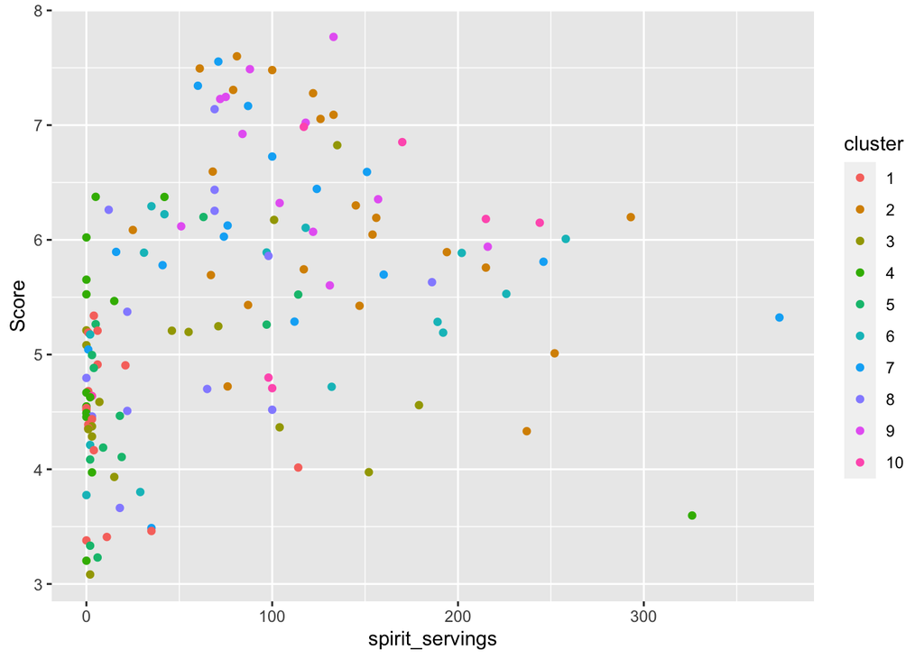

```r
kmeansclust2%>%ggplot(aes(spirit_servings,Score,color=cluster))+geom_point()
```

```r
clust_dat3<-mydata%>%dplyr::select(total_litres_of_pure_alcohol,Score)
for(i in 2:10){
  kms3<-kmeans(clust_dat3,centers=i)
  sil3<-silhouette(kms3$cluster,dist(clust_dat3))
  sil_width3<-mean(sil[,3])
}
ggplot()+geom_line(aes(x=1:10,y=sil_width))+scale_x_continuous(name="k",breaks=1:10)
```

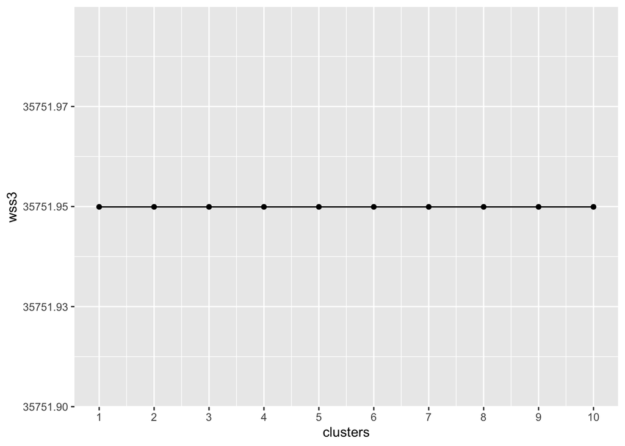

```r
for(i in 1:10){
temp3<- mydata %>% select(total_litres_of_pure_alcohol,Score) %>% kmeans(i)
wss3<-temp2$tot.withinss
}
ggplot()+geom_point(aes(x=1:10,y=wss3))+geom_path(aes(x=1:10,y=wss3))+
  xlab("clusters")+scale_x_continuous(breaks=1:10)
```

```r
kmeans4<-clust_dat%>%kmeans(10)
kmeans4
```

```
## K-means clustering with 10 clusters of sizes 28, 7, 16, 12, 21, 11, 13, 12, 14, 9
##
## Cluster means:
##    beer_servings    Score
## 1       3.678571 4.619286
## 2     349.857143 5.759000
## 3      52.625000 5.097750
## 4     280.166667 6.673417
## 5     217.428571 6.154714
## 6     161.363636 6.221000
## 7      17.846154 4.825000
## 8      29.750000 4.697083
## 9      83.142857 5.319643
## 10    125.666667 5.816333
##
## Clustering vector:
##   1   2   3   4   5   6   7   8   9  10  11  12  13  14  15  16  17  18  20  21
##   4   5   6   5   4   6   6   5   5   4   4   6   3   5   5   4   2   4   2   7
##  22  23  24  26  27  28  29  30  31  32  33  34  35  36  37  38  39  40  41  42
##   6   5  10  10   3   1   1   4   4   5  10   3   3   9   3   5   5   2   8   2
##  43  44  45  47  48  49  50  51  52  53  54  55  56  57  58  59  60  61  62  63
##   6   4   9   5   4   5   6   1   9   4  10   5   9   9   9   9  10   6   5   5
##  65  66  67  69  70  71  72  73  74  75  77  79  80  81  82  83  85  86  87  88
##   6   5   1   9   4  10   1   8   1   5   5   3   7  10  10   9   3   8   7   8
##  89  90  91  92  93  94  95  96  97  98 100 101 102 104 105 106 107 108 109 111
##   7   7   7   1   9  10   7   6   5   8   1   1   8   2   3   5   9   2   3   1
##  [ reached getOption("max.print") -- omitted 43 entries ]
##
## Within cluster sum of squares by cluster:
##  [1]  341.9399 1215.1686  859.4447 3250.9316 6683.8796 1407.6873  141.1870
##  [8]  217.3920 1059.2735 1158.2465
##  (between_SS / total_SS =  99.0 %)
##
## Available components:
##
## [1] "cluster"      "centers"      "totss"        "withinss"     "tot.withinss"
## [6] "betweenss"    "size"         "iter"         "ifault"
```

```r
kmeans4$betweenss
```

```
## [1] 1590387
```

```r
kmeans4$tot.withinss
```

```
## [1] 16335.15
```

```r
kmeans4$size
```

```
##  [1] 28  7 16 12 21 11 13 12 14  9
```

```r
kmeans4$cluster
```

```
##   1   2   3   4   5   6   7   8   9  10  11  12  13  14  15  16  17  18  20  21
##   4   5   6   5   4   6   6   5   5   4   4   6   3   5   5   4   2   4   2   7
##  22  23  24  26  27  28  29  30  31  32  33  34  35  36  37  38  39  40  41  42
##   6   5  10  10   3   1   1   4   4   5  10   3   3   9   3   5   5   2   8   2
##  43  44  45  47  48  49  50  51  52  53  54  55  56  57  58  59  60  61  62  63
##   6   4   9   5   4   5   6   1   9   4  10   5   9   9   9   9  10   6   5   5
##  65  66  67  69  70  71  72  73  74  75  77  79  80  81  82  83  85  86  87  88
##   6   5   1   9   4  10   1   8   1   5   5   3   7  10  10   9   3   8   7   8
##  89  90  91  92  93  94  95  96  97  98 100 101 102 104 105 106 107 108 109 111
##   7   7   7   1   9  10   7   6   5   8   1   1   8   2   3   5   9   2   3   1
##  [ reached getOption("max.print") -- omitted 43 entries ]
```

```r
kmeansclust3<-clust_dat3%>%mutate(cluster=as.factor(kmeans4$cluster))
kmeansclust3
```

```
##    total_litres_of_pure_alcohol Score cluster
## 1                          10.0 7.769       4
## 2                          10.4 7.600       5
## 3                           6.7 7.554       6
## 4                           6.6 7.494       5
## 5                           9.4 7.488       4
## 6                          10.2 7.480       6
## 7                           7.2 7.343       6
## 8                           9.3 7.307       5
## 9                           8.2 7.278       5
## 10                          9.7 7.246       4
## 11                         10.4 7.228       4
## 12                          4.4 7.167       6
## 13                          2.5 7.139       3
## 14                         11.4 7.090       5
```

[output cut: 20 more lines]

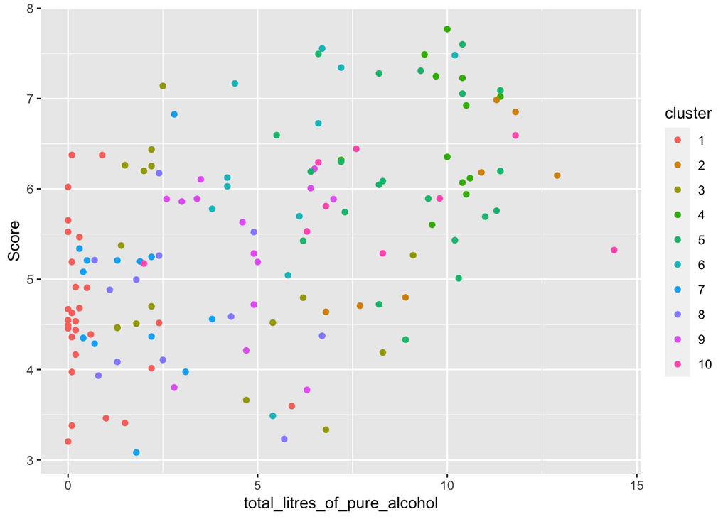

```r
kmeansclust3%>%ggplot(aes(total_litres_of_pure_alcohol,Score,color=cluster))+geom_point()
```

### Rubric

Prerequisite: Finding appropriate data from at least two sources per the instructions above: Failure to do this will result in a 0! You will submit a .Rmd file and a knitted document (html/pdf).

#### 0. Introduction (5 pts)

- Write a narrative introductory paragraph or two describing the datasets you have chosen, the variables they contain, how they were acquired, and why they are interesting to you. Expand on potential associations you may expect, if any.

This project explores the global relationship between alcohol consumption and happiness. I found two datasets that contained a common variable of country and was able to use them for the project. The dataset on drinking contains information on the average consumption per citizen in each country. It examines wine servings, spirit servings, beer servings, total liters, and continent.The dataset on happiness includes each country with a happiness score, GDP per gapita, generosity, perceptions of corruption, healthy life expectancy, social support, and freedom to make life choices.

We are all familiar with the fact that alcohol is a depressant, but I was curious as to what exactly that meant for overall happiness. My underlying question was simply: does drinking more mean you will be a less happy person? There are countries that frequently score high on a “happiness” scale like Denmark and Finland, and I was curious if countries like this drink more while unhappy countries drink less. Because alcohol is a depressant, it’s reasonable to think that there would be a negative association between the two. I actually expected to find the opposite. While alcohol itself has negative impacts on your brain’s ability to feel happy, my instincts told me that countries where drinking is more pervasive might have wealthier citizens, more free time or leisure, more social interaction, etc. For this reason, I expected a positive relationship between alcohol consumption and the happiness score of each country.

#### 1. Tidying: Rearranging Wide/Long (10 pts)

- Tidy the datasets (using the `tidyr` functions `pivot_longer`/`gather` and/or `pivot_wider`/`spread`)
- If you data sets are already tidy, be sure to use those functions somewhere else in your project (e.g., for rearranging summary statistics)
- Document the process (describe in words what was done)

  Both of these datasets were already quite tidy. Each row had a value in each column, the countries in each respective dataset appeared only once, and the columns weren’t repetitive. I used pivot wider on both preliminary datasets, changing “country” to a column instead. This resulted in 150+ additional columns under the formal name of each country with the happiness score or the total liters of alcohol consumed as its value, depending on which dataset I was altering. I then used pivot longer to reverse this change and resume examination of the tidy datasets.

#### 2. Joining/Merging (10 pts)

- Join your datasets into one using a `dplyr` join function
- If you have multiple observations on the joining variable in either dataset, fix this by collapsing via summarize
- Discuss the process in words, including why you chose the join you did
- Discuss which cases were dropped, if any, and potential problems with this

#### 3. Wrangling (40 pts)

- Use all six core `dplyr` functions in the service of generating summary tables/statistics (12 pts)
  - Use mutate at least once to generate a variable that is a function of at least one other variable
- Compute summary statistics for each of your variables using `summarize` alone and with `group_by` (if you have more than 10 variables, fine to just focus on 10) (20 pts)
  - Use at least 5 unique functions inside of summarize (e.g., mean, sd)
  - For at least 2, use summarize after grouping by a categorical variable. Create one by dichotomizing a numeric if necessary
  - If applicable, at least 1 of these should group by two categorical variables
- Summarize the procedure and discuss all (or the most interesting) results in no more than two paragraphs (8 pts)

#### 4. Visualizing (30 pts)

- Create a correlation heatmap of your numeric variables the way we did in class
- Create two more effective, polished plots with ggplot
  - Each plot should map 3+ variables to aesthetics
  - Each plot should have a title and clean labeling for all mappings
  - Change at least one default theme element and color for at least one mapping per plot
  - For at least one plot, add more tick marks (x, y, or both) than are given by default
  - For at least one plot, use the stat=“summary” function
  - Supporting paragraph or two (for each plot) describing the relationships/trends that are apparent

This correlation plot explored the relationship between each of the variables of my tidied, merged dataset. Higher correlation is shown in red, while lower correlation is shown in blue. Because many of my numeric variables looked at the breakdown of alcohol consumption, there was fairly high correlation between many variables. For example, a country with a higher total alcohol servings value will likely have a higher beer, wine, and spirits serving too. For this reason, there’s a lot of red showing up on the correlation plot. The highest correlations are seen between total liters of alcohol and total servings. This makes a lot of sense; more liters of alcohol means more alcohol being consumed in general. It’s unlikely for that to mean the average person is consuming way above average in, say, wine and way below average in another type of alcohol, so it makes sense that these two variables would have a high correlation. The lowest correlation is seen between the happiness score and overall rank. A high happiness score means a lower overall rank because the values are descending. This correlation plot is a little disappointing just because the majority of the striking information comes on semantics as I have discussed above. That being said, I found it interesting that the more “neutral” correlations, or the most lacking correlations are seen in perceptions of corruption. There was very little relationship between the perceptions of corruption and the total servings, total liters, and beer servings. I had debated removing this variable since it didn’t completely align with the questions I had on alcohol as a depressant, but I found it very interesting so I kept it. This correlation plot made me glad I did!

I was inspired to explore the perceptions of corruption variable a bit more. I wanted to see if perceptions of corruption raise or lower as a function of total alcohol servings, so I plotted these variables and used geom_smooth. While the line is satisfying to look at, there doesn’t seem to be a huge relationship here either. The highest serving countries do, however, seem to have the highest perceptions of corruption as well. It’s not apparent from the graph if this relationship is significant, but it would be interesting to look more into the relationship these two variables have.

The final plot I decided to do was looking at total servings by continent. This graph used stat=summary, meaning the mean for each continent was used. The results on this one were by far the most interesting to look at. Adding error bars confirmed my suspicion that there were major differences between the total servings by continent. Africa and Asia were the lowest by a significant amount, while Europe and Oceania were the highest. North and South America fell more in the middle.

#### 5. Dimensionality Reduction (30 pts)

- Either k-means/PAM clustering or PCA (inclusive “or”) should be performed on at least three of your variables (3 is just the minimum: using more/all of them will make this much more interesting!)
  - All relevant steps discussed in class (e.g., picking number of PCs/clusters)
  - A visualization of the clusters or the first few principal components (using ggplot2)
  - Supporting paragraph or two describing results found, interpreting the clusters/PCs in terms of the original variables and observations, discussing goodness of fit or variance explained, etc.

We use k-means to sort the data into “k” clusters on the basis of their stats variables. The centers are moved to the middle of each “cloud of points”; this adjustment changes them to centroids. We repeat this until the groups stabilize. We take each cluster and recompute the center for each one, representing the mean of x and mean of y for each one. Then we reassign the points to whichever centroid they are closest to.

#### 6. Neatness, Holistic/Discretionary Points (5 pts)

- Keep things looking nice! Your project should not knit to more than 30 or so pages (probably closer to 10-20)! You will lose points if you print out your entire dataset(s), have terrible formatting, etc. If you start your project in a fresh .Rmd file, you are advised to copy set-up code below and include it: this will do things like automatically truncate if you accidentally print out a huge dataset, etc. Imagine this is a polished report you are giving to your PI or boss to summarize your work researching a topic.

````r
## paste this chunk into the ```{r setup} chunk at the top of your project 1 .Rmd file

knitr::opts_chunk$set(echo = TRUE, eval = TRUE, fig.align = "center", warning = F, message = F,
tidy=TRUE, tidy.opts=list(width.cutoff=60), R.options=list(max.print=100))
````